# Coursework Report

*N* removed NAs: 3

*N* removed typo: 1

[output not shown]

**Main analysis results**

[interactive chart not shown]

[figure not shown]

[interactive chart not shown]

# Coursework Report

Analysing Data, Spring 2020

# Methods

## Participants

Preceding any manipulation or removal, the raw data consisted of 150 participant observations before data were removed. One reason for this removal was that certain participant’s age data were too low to be included in the study, for it to retain its ethical integrity. For this reason, one observation aged 9, and another, aged 3, were removed - these data units may represent viable particpants, although, due to uncertainty regarding their age, they cannot be included.

Another three participants were removed as their age data appeared as not applicable (NA). A singular unit of age data observation was “1t”, so also could not be included due to the incoherence regarding what age value was intended.

Finally, there were two separate participant observations with the same *id code*. Uncertainty regarding which of these were genuine to either participant, or whether the same participant had data recorded twice, elicited their removal. After the exclusion of these units, the sample consisted of *142* particpant observations to be used - *70* in the *Control* condition, *72* in the *Experimental* condition.

*Figure 1* contains a summary of particiapant age data by test condition:

Figure 1

| Condition | Count (N) | % of Participants per Condition | Mean Age | Standard Deviation |
| --- | --- | --- | --- | --- |
| Control | 70 | 49.3 | 20.01 | 2.32 |
| Experimental | 72 | 50.7 | 19.62 | 2.85 |

## Design

The conceptual hypothesis for this study is *The associations with the colour red for a stimulus will increase the perceived attractiveness of said stimulus*.

The independent variable for the study was the condition under which the participant was tested in, this being either *Experimental* (red stimulus), or *Control* (white stimulus). The independent variable is a factor, with the levels of *Experimental* and *Control*. Participants were randomly assigned to a test condition.

The dependent variable for the study was the attractiveness rating the particpants scored three separate stimulus items. For each participant, the mean of each of their scores was calculated, and presented as graphed data. The dependent variable was a rating variable with possible scores ranging from 1 to 9. A likert-type scale was used to score each stimulus, this way, scores can be compared relatively to each other between participants.

The mean for all collected data (across each item) is 5.807. This measure provides an indication of the average score assigned to an item (irrelevant of condition). The lower quartile for each item was a score of 5, therefore any score below this can be viewed as a low score. The upper quartile for item 1 was 6, and 7 for item 2 and 3. This indicates that a score above these values can be considered a high score.

The operational hypothesis for this study is as follows: **Participants in the Experimental condition will, on average, provide greater composite attractiveness scores than participants in the Control condition.**

The statistical test that will be used to test this hypothesis will be an **independent t-test**.

# Results

*Figure 2*

```
##
##  Welch Two Sample t-test
##
## data:  item_comp by group
## t = 3.9435, df = 139.81, p-value = 0.0001265
## alternative hypothesis: true difference in means is not equal to 0
## 95 percent confidence interval:
##  0.2642335 0.7955549
## sample estimates:
##      mean in group Control mean in group Experimental
##                   6.076190                   5.546296
```

*Figure 3* displays mean composite rating scores by test condition:

Figure 3

| Condition | Count (N) | Mean Composite Rating |
| --- | --- | --- |
| Control | 70 | 6.08 |
| Experimental | 72 | 5.55 |

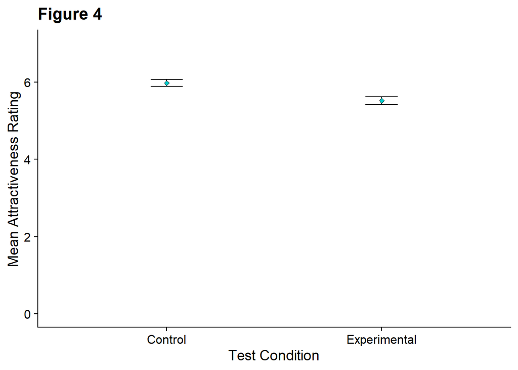

# Discussion

The original conceptual hypothesis presumed that, in the presence of stimuli with red features, invoked levels of participant attraction in response would be, on average, greater than the response to stimuli with white-coloured features. The findings of this study, however, contradict this hypothesis. The direction of difference (mean Control score greater than Experimental condition mean/ negative b1) indicates alone that the study results contradict the alternative hypothesis. In opposition to the alternative hypothesis, the significance of b1 may suggest an effect in the other direction.*

Studies on the same topic of research other than this have found both promoting and opposing the existence of any effect. For example, Elliot et al. (2010) found that the colour red does have an enhancing effect on women’s perceived attractiveness of the same male stimulus, therefore supporting this study’s alternative hypothesis. Considering pre-existing findings such as these, this study’s findings contradict those of particular previous studies.

Some methodological strengths of this study involve the operationalisation of the it’s variables. The ordinal measurement system used to record perceived attractiveness was constructed and measured objectively (dependent variable), as well as the differentiating stimulus factors between test conditions (independent variable). Another strength to be derived from the study is the significance of the result. Although the research findings displayed a result antithetic to its hypothesis, this feature of the research outcome may indicate the existence of an opposing phenomenological effect (colour white may enhance perceived attractiveness). Although this is unlikely as, other than this study’s findings, there is little empirical backing to this effect existing, this significance may suggest the investigation into an opposing effect (as stated) proving worthwhile.

A purposeful limitation of this study to consider is its rather small sample size. Considering the unlikelihood of an effect existing in the direction opposite to that of what the study predicted, the significant result may be caused by the simple fact of an inadequate amount of participants. In this case, if the results of this study are to contribute to a definitive conclusion on the topic area in question, then a verdict of no effect of the colour red influencing perceived attractiveness would be appropriate.

# References

Elliot, A. J., Kayser, D.N., Greitemeyer, T., Lichtenfeld, S., Gramzow, L.H., Maier, M.A (2010). Red, Rank, and Romance in Women Viewing Men. *Journal of Experimental Psychology: General, 2010*, *139*(3), 399–417

Peperkoorn, L.S., Roberts, S.C., Pollet, T.V (2016). Revisiting the Red Effect on Attractiveness and Sexual Recpetivity: No Effect of the Colour Red on Human Mate Preferences. *Journal of Evolutionary Psychology*, *14*(4)